# 银行客户画像分析

Jason

1/24/2020

## Information about the dataset

The dataset is from the website: http://archive.ics.uci.edu/ml/datasets/Bank+Marketing.

The data is related with direct marketing campaigns (phone calls) of a Portuguese banking institution. The classification goal is to predict if the client will subscribe a term deposit (variable y). The data is related with direct marketing campaigns of a Portuguese banking institution. The marketing campaigns were based on phone calls. Often, more than one contact to the same client was required, in order to access if the product (bank term deposit) would be (‘yes’) or not (‘no’) subscribed.

## Attribute Information:

## Input variables:

### bank client data:

1 - **age** (numeric)

2 - **job** : type of job (categorical:‘admin.’,‘blue-collar’,‘entrepreneur’,‘housemaid’,‘management’,‘retired’,‘self-employed’,‘services’,‘student’,‘technician’,‘unemployed’,‘unknown’)

3 - **marital** : marital status (categorical: ‘divorced’,‘married’,‘single’,‘unknown’; note: ‘divorced’ means divorced or widowed)

4 - **education** (categorical: ‘basic.4y’,‘basic.6y’,‘basic.9y’,‘high.school’,‘illiterate’,‘professional.course’,‘university.degree’,‘unknown’)

5 - **default**: has credit in default? (categorical: ‘no’,‘yes’,‘unknown’)

6 - **housing**: has housing loan? (categorical: ‘no’,‘yes’,‘unknown’)

7 - **loan**: has personal loan? (categorical: ‘no’,‘yes’,‘unknown’)

### related with the last contact of the current campaign:

8 - **contact**: contact communication type (categorical: ‘cellular’,‘telephone’)

9 - **month**: last contact month of year (categorical: ‘jan’, ‘feb’, ‘mar’, …, ‘nov’, ‘dec’)

10 - **day_of_week**: last contact day of the week (categorical: ‘mon’,‘tue’,‘wed’,‘thu’,‘fri’)

11 - **duration**: last contact duration, in seconds (numeric). Important note: this attribute highly affects the output target (e.g., if duration=0 then y=‘no’). Yet, the duration is not known before a call is performed. Also, after the end of the call y is obviously known. Thus, this input should only be included for benchmark purposes and should be discarded if the intention is to have a realistic predictive model.

### other attributes:

12 - **campaign**: number of contacts performed during this campaign and for this client (numeric, includes last contact)

13 - **pdays**: number of days that passed by after the client was last contacted from a previous campaign (numeric; 999 means client was not previously contacted)

14 - **previous**: number of contacts performed before this campaign and for this client (numeric)

15 - **poutcome**: outcome of the previous marketing campaign (categorical: ‘failure’,‘nonexistent’,‘success’)

### social and economic context attributes

16 - **emp.var.rate**: employment variation rate - quarterly indicator (numeric)

17 - **cons.price.idx**: consumer price index - monthly indicator (numeric)

18 - **cons.conf.idx**: consumer confidence index - monthly indicator (numeric)

19 - **euribor3m**: euribor 3 month rate - daily indicator (numeric)

20 - **nr.employed**: number of employees - quarterly indicator (numeric)

### Output variable (desired target):

21 - **y** - has the client subscribed a term deposit? (binary: ‘yes’,‘no’)

```r
library(ggplot2)
library(dplyr)
library(mice) # deal with missing values by serval regressions or cart
library(VIM) # visualize missing values
library(randomForest)
library(rfUtilities)
library(MLmetrics)
library(MASS)
library(corrplot) # visualize corrleation
library(psych) # pca
library(ggfortify) # visualize pca
```

```r
dataset <- read.csv('C:/Users/jasonguo/Desktop/bank-additional/bank-additional-full.csv', sep=";")
# 数据概况
head(dataset,n=1)
```

```
##   age       job marital education default housing loan   contact month
## 1  56 housemaid married  basic.4y      no      no   no telephone   may
##   day_of_week duration campaign pdays previous    poutcome emp.var.rate
## 1         mon      261        1   999        0 nonexistent          1.1
##   cons.price.idx cons.conf.idx euribor3m nr.employed  y
## 1         93.994         -36.4     4.857        5191 no
```

```r
# 数据的总结
sprintf('变量数目: %d',length(dataset)-1)
```

```
## [1] "变量数目: 20"
```

```r
sprintf('样本数目: %d',41188)
```

```
## [1] "样本数目: 41188"
```

```r
summary(dataset$y) # 选择定期存款的人
```

```
##    no   yes
## 36548  4640
```

## 数据预处理

```r
# 去除 duration
dataset <- subset(dataset, select=-c(duration))

# 处理缺失数据
dataset <- na_if(dataset,"unknown") # 转化为na
sapply(dataset, function(x) sum(is.na(x))) # 多少na在每列
```

```
##            age            job        marital      education        default
##              0            330             80           1731           8597
##        housing           loan        contact          month    day_of_week
##            990            990              0              0              0
##       campaign          pdays       previous       poutcome   emp.var.rate
##              0              0              0              0              0
## cons.price.idx  cons.conf.idx      euribor3m    nr.employed              y
##              0              0              0              0              0
```

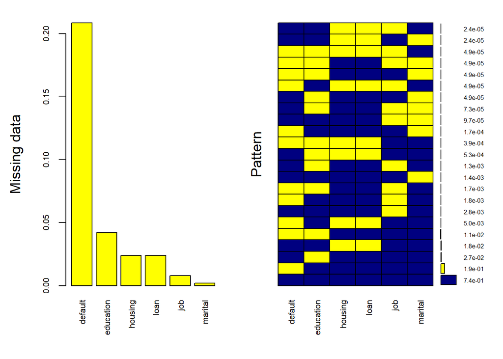

```
##
##  Variables sorted by number of missings:
##   Variable       Count
##    default 0.208725842
##  education 0.042026804
##    housing 0.024036127
##       loan 0.024036127
##        job 0.008012042
##    marital 0.001942313
```

```r
## 可视化分析
miss_sample <- subset(dataset, select=c('default','education','housing','loan','job','marital')) # 选择有缺失值的
miss_plot <- aggr(miss_sample, col=c('navyblue','yellow'),
                  numbers=TRUE, sortVars=TRUE,
                  labels=names(miss_sample), cex.axis=.7,
                  cex.numbers=0.5, ylab=c("Missing data","Pattern"))
```

左边显示缺失比例和排序，右边显示缺失值的模式以及每种模式的概率大小,比如前两种同时都没有的比例是1.1%。分析发现人们对于是否以往有违约缄默其口，其次是学历情况.最后我发现未透露是否有房贷信息的人同样不愿意透露是否有个人贷款。

```r
# transform y into a dummy variable
dataset<-dataset %>%
  mutate(y = ifelse(y == "no",0,1))
target <- dataset$y
dataset <- subset(dataset, select=-c(y))
```

```r
## 填补缺失值
imputed_Data <- mice(dataset, m=5, maxit = 5, method = 'cart', seed = 500) # 选用 Classification and regression trees
```

一共五个新的dataset，全部进行数据预处理并且导出：

```r
processed_data <- c('processed_data1','processed_data2','processed_data3','processed_data4','processed_data5')
for (i in c(1:5)){
  completeData <- complete(imputed_Data,i)
  # Numerical variables: age, campaign, pdays, previous, emp.var.rate, cons.price.idx, cons.conf.idx, euribor3m, nr.employed
  # Normalize numerical variables: z-score 标准化
  numer <- c('age','campaign','pdays','previous', 'emp.var.rate', 'cons.price.idx', 'cons.conf.idx', 'euribor3m', 'nr.employed')
  for (each in numer){
    temp <- scale(completeData [each])
    completeData [each] <- temp
  }

  # one-hot encoding category variables
  cat <- c('job','marital','education','default','housing','loan','contact','month','day_of_week','poutcome')
  for (each in cat){
    temp <- model.matrix(formula(paste("~",each,-1)),completeData) %>% as.data.frame()   # one-hot encoding, paste for loops
    completeData <- cbind(completeData, temp) # 合并
  }
  completeData <- completeData[, -match(cat,names(completeData)), drop=F] # 删除原有列

  # 去除全是0的列,因为已经被填补
  zeros <- c('loanunknown','housingunknown','defaultunknown','educationunknown','maritalunknown','jobunknown')
  completeData <- completeData[, -match(zeros,names(completeData)), drop=F] # 删除

  # 重命名一些列
  names(completeData)<-make.names(names(completeData)) # 一些如“-”不合规

  assign(processed_data[i],completeData)

  }
```

Merge target

```r
processed_data1<-cbind(processed_data1, target)
processed_data2<-cbind(processed_data2, target)
processed_data3<-cbind(processed_data3, target)
processed_data4<-cbind(processed_data4, target)
processed_data5<-cbind(processed_data5, target)
```

写出所有

```r
write.csv(processed_data1, file = 'processed_data1.csv')
write.csv(processed_data2, file = 'processed_data2.csv')
write.csv(processed_data3, file = 'processed_data3.csv')
write.csv(processed_data4, file = 'processed_data4.csv')
write.csv(processed_data5, file = 'processed_data5.csv')
```

到这里数据预处理就完成了。。。接着继续分析。。。